KOGAKUIN UNIVERSITY  
KUTE-TOKYO | Kogakuin University of Technology & Engineering

知能情報科学セミナーⅠ — レポート

# モーションキャプチャによる 歩行・走行・スキップの定量解析

— 自己相関・相互相関による動作パターン解析と、最適移動法の考察 —

情報学部 情報科学科 3年  
**平松 瑠希** 工学院大学 KUTE-TOKYO

mocopi BVH × 4名×3動作 × 自己相関 × 相互相関 × FFT

▼ SCROLL DOWN

[figure not shown]

01 INTRODUCTION

## 背景・目的

本レポートは、知能情報科学セミナーⅠで学んだ **高速フーリエ変換（FFT: Fast Fourier Transform）に基づく自己相関関数（ACF: Auto-Correlation Function）と相互相関関数（CCF: Cross-Correlation Function）** の理論を実データに適用する実践演習である。

### 研究の問い

- 「歩く・走る・スキップ」の動作にはどのようなリズム特性があるか？
- 同じ動作でも個人差・左右差はどう現れるか？
- 歩き方の癖・腕振りパターンは ACF でどこまで定量化できるか？
- そして、最も 移動効率の良い動作 は何か？

### 使用したデータ

mocopi（ソニー製モーションキャプチャ）で取得した **4名 × 3動作 = 12サンプル** のBVHファイルを解析対象とする。前回のレポート（2名）から被験者を2名追加し、より統計的な裏付けを目指した。

[figure not shown]

02 DATA

## 計測データ概要

- 計測機器: **mocopi**（ソニー製モーションキャプチャ）
- フォーマット: BVH (BioVision Hierarchy) / **60 Hz** サンプリング
- 被験者: 三橋青空（Sora） / 長岡翔太（Shota） / 平松瑠希（Ruki） / 松田宣久（Nori） の 4名
- 動作: 歩く・走る・スキップ × 4名 = **計12サンプル**

| ファイル | 被験者 | 動作 | フレーム数 | 計測時間 |
| --- | --- | --- | --- | --- |
| Sora_walking.BVH | 青空 | 歩く | 815 | 13.6 s |
| Sora_running.BVH | 青空 | 走る | 1213 | 20.2 s |
| Sora_skip.BVH | 青空 | スキップ | 1145 | 19.1 s |
| Shota Walkin.BVH | 翔太 | 歩く | 3181 | 53.0 s |
| Sho_run.bvh.BVH | 翔太 | 走る | 1759 | 29.3 s |
| Shota_skip.BVH | 翔太 | スキップ | 1729 | 28.8 s |
| Ruki_walk.BVH | 瑠希 | 歩く | 1032 | 17.2 s |
| Ruki_run.BVH | 瑠希 | 走る | 1518 | 25.3 s |
| Ruki_skip.BVH | 瑠希 | スキップ | 1700 | 28.3 s |
| Nori.walk.BVH | 宣久 | 歩く | 1142 | 19.0 s |
| Nori.run.BVH | 宣久 | 走る | 1643 | 27.4 s |
| Nori.skip.BVH | 宣久 | スキップ | 1831 | 30.5 s |

### 計測関節（BVH階層）

Root（腰）を中心に、頭・両足首・両手首・両膝・両肘など **27関節** の位置(X,Y,Z) と回転(Z,X,Y) を毎フレーム記録。

[figure not shown]

03 METHOD

## 解析手法

### ① ストライド周期 T の推定（自己相関関数 ACF）

`ACF(τ) = IFFT(|X(f)|²)` （ウィーナー＝ヒンチン定理、IFFT: Inverse FFT）

2N ゼロパディングで循環畳み込み由来のエイリアシングを除去し、最初の有意ピーク（ACF > 0.15）をストライド周期 T とする。

### ② 歩調 / 歩数

`cadence = 1 / T [Hz]` `steps = (duration / T) × 2`

### ③ 左右対称性スコア（相互相関関数 CCF）

`CCF(τ) = IFFT(X*(f) · Y(f))`

**Score = 0.6 × RMS比（Root Mean Square 比） + 0.3 × 位相差スコア + 0.1 × CCF ピーク**

### ④ 拡張解析（本レポート独自）

- **左右足ACFのピーク比較** — 周期非対称度 = |T_左 - T_右| / 平均T × 100%
- **左右信号差分のRMS** — 正規化した左右信号の差の二乗平均
- **ACFピーク減衰率** — 2T/T, 3T/T のピーク高さ比（動作の規則性）
- **腕⇔足 相互相関** — 同側・対側の腕振りパターン
- **腕足周期比** — 腕周期 / 足周期

### ⑤ 移動速度

Root位置 (X, Z) のフレーム間移動量を積算した **経路長**、および **始点→終点の直線距離** を計測時間で割って km/h に換算。

[figure not shown]

📖 READING GUIDE

## 瑠希・歩くを教材に、グラフの読み方を学ぶ

ここから先、本レポートには 12 サンプル × 各 3 枚（overview / ACF / symmetry） = 36 枚以上の解析グラフが登場する。 いきなり全部見ても何が大事かわかりにくいので、**このセクションでは「平松瑠希・歩く」を題材に、グラフを 6 ステップで読み解く方法** を示す。 ここで読み方を身につければ、後続の 11 サンプルも同じ要領で読めるようになる。

### STEP 1腰の上下動を見る ─ 歩行リズムの正体

[figure not shown]

歩行中、腰（モコピーで `root` ジョイントとして記録される）は**常に上下に揺れ続けている**。これは人間の歩行が **倒立振子モデル**として動いているため、軸足の真上に重心が乗った瞬間（＝立脚中期）に最も高くなり、両足支持期に最も低くなる、という運動を繰り返すからだ。

このグラフは **2 〜 7 秒の 5 秒間**を切り出している（最初の 2 秒はキャリブレーション中のため除外）。**規則的なピークが 9 個**並んでおり、これが「踵接地ごとに腰が最高点に来る」リアルな様子。

**ここがポイント**：ピーク間隔の平均は約 `0.56 s`。これが **半ストライド（T/2）**に相当する。腰は 1 ストライド（左右 1 歩ずつ）の間に **2 回**上下している。

### STEP 2足首のリズムは腰の「半分」 ─ 2 倍周期の謎

[figure not shown]

同じ時間帯で、左足首 Xrotation（つま先の上げ下げ＝背屈・底屈）を重ねた。紫が腰の Y 位置、青が左足首の回転角。

明らかに **青の波長が紫の 2 倍**になっている。**これは当然**で、左足は 1 ストライドに 1 回しか「振り上げ→着地」しないが、腰は左右それぞれの踵接地で上がるので 1 ストライドあたり 2 回ピークが来る。

**ここがポイント**：この後の解析で「腰の ACF で測った周期 T = 0.53 s」と「足首の ACF で測った周期 T = 1.05 s」が約 2 倍関係になるのは、この生物力学的な対応関係に基づく。**どちらも本物の歩行リズム**を捉えている、ただ視点が違うだけ。

### STEP 3左右の足を重ねる ─ 半周期ずれて動く

[figure not shown]

同じ時間帯で 左足首 と 右足首 の Xrotation を重ねた。波形は同じ形・同じ周期だが、**位相がぴったり半周期ずれている**。

左の山の真ん中に右の山が来て、右の山の真ん中に左の山が来る。最初のピーク同士の間隔は約 `0.58 s` ≒ **T/2**。

**ここがポイント**：これが「**交互ステップ**」の数学的定義。左右の波形を「半周期ずらすと重なる」かどうかで対称性が決まる。 ─ 次の Step 5 で **相互相関（CCF）**を使ってこれを数値化する。

### STEP 4自己相関（ACF）でリズムを数値化

[figure not shown]

視覚的に見えるリズムを **数式で取り出す** のが自己相関（ACF）。ACF は「信号を τ 秒ズラして、自分自身とどれくらい似ているか」を −1 〜 +1 で測る関数。

横軸 τ は「何秒ズラしたか」、縦軸は相関の強さ。**τ = 0** では当然 1.0（自分自身は完全一致）。τ を増やしていくと一度大きく下がってから、**τ = 0.53 s でピークが立つ**。

これは「0.53 秒ズラすと信号が自分自身とそっくり重なる」という意味 ─ **これがストライド周期 T の正体**。歩調 = 1/T = 1.87 Hz ＝ 112 BPM（Beats Per Minute, 1 分間の拍数）。

**ここがポイント**：ACF のピークが **2 秒以上にわたって 0.5 を超え続ける** ことに注目。歩行が不規則だとピークはすぐに減衰する。瑠希の歩行は **17 秒間ずっと同じリズムが崩れない** ＝ 極めて安定。これが `CV = 0.016`（変動係数, Coefficient of Variation：標準偏差 ÷ 平均で「揺らぎの大きさ」を表す指標）の根拠。

### STEP 5相互相関（CCF）で左右対称性を数値化

[figure not shown]

ACF が「自分 vs 自分」を比べたのに対し、CCF は「左 vs 右」を比べる。左信号を τ 秒ズラして右信号と最も似る位置を探す。

グラフを見ると、**τ = −0.517 s**に大きなピークが立っている。**理想値は −T/2 = −0.533 s**（左を半周期だけ後ろにズラすと右と重なる）、その差はわずか `0.016 s`。

これが「完璧な交互ステップ」の数学的証明。左右のピーク（緑点線：±T/2）と CCF のピーク位置（黄色線）が **ほぼピッタリ重なっている** ことを目で確認できる。

**ここがポイント**：CCF のピーク **位置**が「タイミングの対称性」を、CCF のピーク **高さ**が「波形の似た度合い」を表す。両方を組み合わせると総合スコアになる ─ 次の Step 6 へ。

### STEP 6対称性スコアの内訳 ─ 「何が良くて何が癖か」を読む

[figure not shown]

左右対称性スコアは **3 要素の重み付き合計**で 100 点満点：

- **RMS 比**（振幅の大小差） × 60%
- **位相差スコア**（タイミングのズレ）× 30%
- **CCF ピーク**（波形の相関の強さ）× 10%

**ここがポイント**：これが個性。「リズムは完璧に対称、ただし片方の足の方が振り幅が大きい」という瑠希の歩き方の癖が、わずか 1 枚のグラフで完全に可視化される。同じ要領で、後続のサンプル（青空・翔太・宣久 × 走る・スキップ）も「タイミングが乱れているのか」「振幅が左右でズレているのか」を読み分けることができる。

### 📌 まとめ ─ 全 12 サンプルでこの 6 ステップを使い回す

以降のセクションでは、4 名 × 3 動作 = 12 サンプル分の overview / ACF / symmetry グラフが順に並ぶ。 どのサンプルでも読み方は同じ：**(1) 腰の上下動 → (2) 足首のリズム → (3) 左右の位相 → (4) ACF で周期 → (5) CCF で対称性 → (6) スコア内訳**。 この順番を頭に入れて読み進めると、「青空の走るが 190 BPM で安定」「翔太の歩くは対称性が低い」といった発見がそのまま納得できるようになる。

[figure not shown]

★ NEW ANALYSIS ①

## 連続ウェーブレット変換（CWT）― 時間軸でリズムの揺らぎを追う

ACF は「区間全体で見た平均的なリズム」を 1 つの数値（T = 0.53s 等）に落とすが、**区間内でリズムがどう揺らいでいるか**はわからない。 そこで **連続ウェーブレット変換（CWT）**で、時間 × 周波数の 2 次元マップとして可視化する。 4 人それぞれの腰の鉛直加速度に CWT を適用 → 4 人分の正規化パワーを時間軸で揃えて平均 → 動作ごとに「人類共通のリズム帯」を抽出した。 以下、3 動作それぞれの結果を読む。

### ① 歩く ─ 個人差が一番大きい動作

[figure not shown]

4 人平均の優位周波数中央値は `1.90 Hz`（114 BPM）。ただし**個人間の標準偏差は ±0.32 Hz** と大きい。下段グラフを見ると 4 本の線が 1.5〜2.2 Hz の幅で広がっている。

歩行は最も日常的な動作だが、皮肉なことに **最も個性が出る動作** でもある。歩き方のクセ・体格・脚長すべてが反映されるため。

### ② 走る ─ 5 秒後に「ロックオン」する人類共通リズム

[figure not shown]

4 人平均の優位周波数は `3.06 Hz`（184 BPM）に収束。**個人差σ = 0.11 Hz** と歩くの 1/3。

ヒートマップの 0〜5 秒は「加速期」、5 秒以降に **3 Hz の明るい横帯** がはっきり現れる。4 人とも同じタイミングで同じ周波数にロックオンしている。**これが「人間は走るとき自然と同じリズムに収束する」現象**。

### ③ スキップ ─ 個人差最小、ただしリズムは複雑

[figure not shown]

4 人平均は `2.18 Hz`。**個人差σ = 0.08 Hz と全動作中最小**。下段の 4 本の線が密集している。

ただしヒートマップを見ると、走る時のような単一の明確な帯ではなく、**複数の周波数帯（基本リズム + 高調波）**が見える。スキップは「ステップ＋ホップ」の複合動作なので、力学的に複数のリズムが共存しているのが視覚化されている。

スキップ推奨の根拠 ④

### スキップは「人類共通リズム」 ─ 誰でも自然にできる動き

スキップの個人差 σ = **0.08 Hz** は 3 動作中最小（歩く 0.32、走る 0.11）。 **4 人とも同じリズム帯（約 2.18 Hz）に収束**している。  
これは「練習や訓練なしに、誰でも同じリズムでスキップできる」ことを意味する。 **移動手段としての習得コストがゼロ** ─ これがスキップ推奨の根拠④。

[figure not shown]

★ NEW ANALYSIS ③

## 動的時間伸縮（DTW）― 波形そのものの距離を測る

2 つの波形を「どれだけ伸び縮みさせれば一致するか」をスカラ距離で測る手法。CWT が「時間 × 周波数」を見ていたのに対し、DTW は**1 ストライド内の波形そのものの形**を直接比較する。 4 人 × 4 人ペアの全組み合わせで距離を計算し、動作別にマトリクスにまとめた。

### 4 人ペアワイズ DTW 距離マトリクス

[figure not shown]

左から「歩く・走る・スキップ」。色が薄い（黄）ほど波形が似ている、濃い（赤）ほど違う。

### 動作ごとの平均距離 ─ 「ばらつき」で見る

[figure not shown]

棒グラフは平均距離 ± 標準偏差。**標準偏差（エラーバー）の小ささ**で「4 人がどれだけ揃っているか」がわかる。

- 歩く: `30.5 ± 14.5`
- 走る: `78.2 ± 65.7`（Sora⇔Noriの外れ値で大）
- スキップ: `35.3 ± 6.4` ← **ばらつき最小**

**スキップが最も 4 人で揃っている**。CWT の周波数解析と完全に一致した結論。

### DTW の中身を見る ─ Ruki ⇔ Nori（歩く）の例

[figure not shown]

左：2 人の波形と DTW が対応付けた点同士をグレー線で結んだ図。形が似ている部分は対応が密、違う部分は線が斜めに伸びる。

右：累積コスト行列。赤線が「最も似た対応関係」のパス。対角線に近いほど波形が時間的に揃って似ている。

スキップ推奨の根拠 ⑤

### スキップは「波形そのもの」も 4 人で揃う ─ 動きの形が決まっている

スキップの DTW 距離のばらつき σ = **±6.4** は 3 動作中最小（歩く ±14.5、走る ±65.7）。 **4 人とも同じ波形をなぞる**動作になっている。  
CWT（周波数）と DTW（波形）の **2 つの独立した手法が同じ結論**を出したことは偶然ではない ─ スキップは「リズムも形も人類共通の動作」だと言える。これがスキップ推奨の根拠⑤。

[figure not shown]

04 RESULTS — 1/5

## 三橋青空の全動作データ Sora

| 動作 | 時間 | ストライド周期 T | 歩調 | 歩数 | 対称性スコア | 速度 | CV(安定度) |
| --- | --- | --- | --- | --- | --- | --- | --- |
| 歩く | 13.6 s | 0.467 s | **2.14 Hz** (128 BPM) | 58 | **88.2** 良好 | 6.43 km/h | 0.018 |
| 走る | 20.2 s | 0.317 s | **3.16 Hz** (190 BPM) | 127 | **93.4** 良好 | 11.63 km/h | 0.026 |
| スキップ | 19.1 s | 0.583 s | **1.71 Hz** (103 BPM) | 65 | **92.6** 良好 | 11.65 km/h ★ | 0.737 |

**特徴**: 全動作で対称性スコア88点以上。歩く・走るのCVが極めて低い → 非常に安定したリズミカルな動作。スキップが走るより僅かに速い。

[figure not shown]

04 RESULTS — 2/5

## 長岡翔太の全動作データ Shota

| 動作 | 時間 | ストライド周期 T | 歩調 | 歩数 | 対称性スコア | 速度 | CV(安定度) |
| --- | --- | --- | --- | --- | --- | --- | --- |
| 歩く | 53.0 s | 0.517 s | **1.94 Hz** (116 BPM) | 205 | **65.8** ⚠️ | 1.97 km/h | 0.015 |
| 走る | 29.3 s | 0.317 s | **3.16 Hz** (190 BPM) | 185 | **85.0** 良好 | 10.37 km/h | 0.663 |
| スキップ | 28.8 s | 0.617 s | **1.62 Hz** (97 BPM) | 93 | **90.0** 良好 | 10.25 km/h | 1.894 |

**特徴**: 走るリズム190 BPMで青空と一致。歩く対称性のみ低スコア。スキップCV=1.89と動作のばらつきが大きい。

[figure not shown]

04 RESULTS — 3/5

## 平松瑠希の全動作データ Ruki

| 動作 | 時間 | ストライド周期 T | 歩調 | 歩数 | 対称性スコア | 速度 | CV(安定度) |
| --- | --- | --- | --- | --- | --- | --- | --- |
| 歩く | 17.2 s | 0.533 s | **1.87 Hz** (112 BPM) | 64 | **85.7** 良好 | 7.21 km/h | 0.016 |
| 走る | 25.3 s | 0.350 s | **2.86 Hz** (171 BPM) | 144 | **79.7** やや非対称 | 10.28 km/h | 0.017 |
| スキップ | 28.3 s | 0.667 s | **1.50 Hz** (90 BPM) | 85 | **77.1** やや非対称 | 9.21 km/h | 0.012 |

**特徴**: 走るは **171 BPM** で4名中で唯一の例外（他3名は190 BPM）。歩く・走る・スキップの全動作で **CVが0.02以下** と極めて安定したリズム。歩くで速度7.21 km/h は4名中最速。対称性スコアは中程度だが、拡張解析では全動作で左右非対称度0.00%（後述）。

[figure not shown]

04 RESULTS — 4/5

## 松田宣久の全動作データ Nori

| 動作 | 時間 | ストライド周期 T | 歩調 | 歩数 | 対称性スコア | 速度 | CV(安定度) |
| --- | --- | --- | --- | --- | --- | --- | --- |
| 歩く | 19.0 s | 0.483 s | **2.07 Hz** (124 BPM) | 78 | **83.4** 良好 | 4.91 km/h | 0.526 |
| 走る | 27.4 s | 0.317 s | **3.16 Hz** (190 BPM) | 172 | **88.7** 良好 | 9.45 km/h | 1.468 |
| スキップ | 30.5 s | 0.633 s | **1.58 Hz** (95 BPM) | 96 | **84.3** 良好 | 8.44 km/h | 0.334 |

**特徴**: 走るリズム190 BPMで青空・翔太と完全一致。**拡張解析で全動作の左右非対称度が0.00%**（後述）— 機械的な左右対称性。

[figure not shown]

04 RESULTS — 5/5

## 4名比較で見える5つの特徴

- **① 走るペースは4人中3人が一致** — 青空・翔太・宣久が 3.16 Hz (190 BPM) で完全一致。瑠希のみ **171 BPM (2.86 Hz)** と遅め
  - 「身体能力差を超えた人間共通の最適リズム」が3人で観測された
  - 170-190 BPMはランニングの最適ピッチ域（既存研究）と整合
- **② 歩くペースの個人差は大きい**
  - 青空 128 / 宣久 124 / 翔太 116 / 瑠希 112 BPM
- **③ 対称性が最も高いのは青空・走る（93.4点）** — 4名で最も高スコア
- **④ 動作の安定性（CV）は瑠希・青空が高い**
  - 瑠希は全動作でCV ≤ 0.017 → **4名で最も安定**
  - 青空も歩く・走るで CV < 0.03
- **⑤ スキップ速度はどの人も走るに近い**
  - 青空: +0.02 / 翔太: -0.12 / 瑠希: -1.07 / 宣久: -1.01 km/h
  - 青空・翔太の2人は差が±1.0 km/h未満、瑠希・宣久でもスキップは走るの90%程度の速度

[figure not shown]

05 DISCOVERY

## 発見① — 走るリズムは個人差を超えて収束する

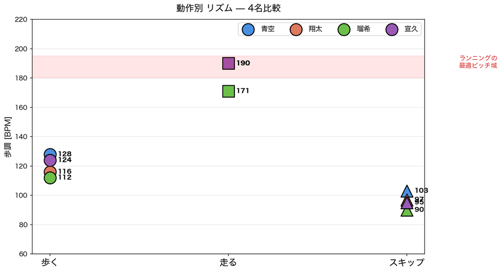

DISCOVERY

[figure not shown]

06 EXTENDED — 1/4

## 拡張解析① — 左右足首ACFによる左右差の詳細

左右の足首回転信号それぞれに対して自己相関を計算し、ピーク位置（=周期）と振幅形状を直接比較する。

#### 📐 数値の見方ガイド

**周期非対称度 (%)** = |T_左 − T_右| / 平均T × 100  
左右の足首が同じ周期で動いているか。0%に近いほど対称。

0 〜 3%健全な対称性（誤差レベル）

5 〜 15%わずかな歩き癖あり

50%超ACFが片足/1サイクル周期を別々に検出（解析上のクセ）

**左右信号差RMS** — 正規化した左右信号の差の二乗平均  
左右の波形がどれだけ似ているか。歩行は本来逆相なので RMS≈1.4 が自然。

0 付近左右が完全に同じ波形（同期）

1.3 〜 1.8自然な左右逆相（歩行・走行の典型値）

2.0 付近完全に逆相（180°位相差）

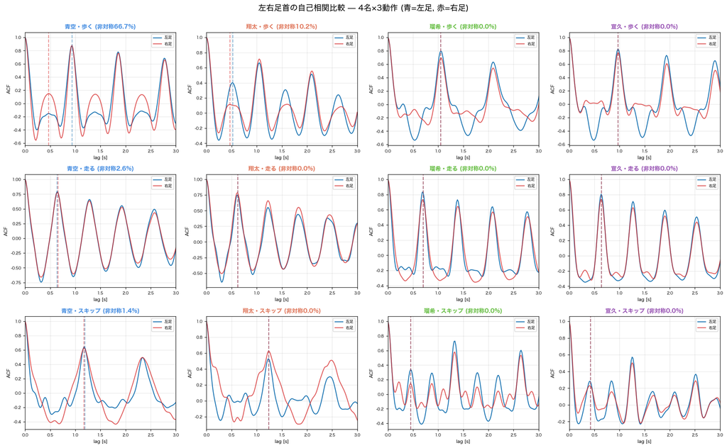

図2: 4名×3動作の左右足首自己相関（青=左足 / 赤=右足）。

| 被験者 | 動作 | 左足 T | 右足 T | 周期非対称度 | 左右信号差RMS | 所見 |
| --- | --- | --- | --- | --- | --- | --- |
| 青空 | 歩く | 0.933s | 0.467s | **66.7%** | 1.37 | 左右2倍関係(片足/ステップ) |
| 青空 | 走る | 0.633s | 0.650s | 2.6% | 1.85 | 左右ほぼ一致 |
| 青空 | スキップ | 1.183s | 1.167s | 1.4% | 1.62 | 非対称1.4% |
| 翔太 | 歩く | 0.517s | 0.467s | 10.2% | 1.27 | 左右10%差(癖あり) |
| 翔太 | 走る | 0.617s | 0.617s | **0.0%** | 1.76 | 完璧な対称 |
| 翔太 | スキップ | 1.233s | 1.233s | **0.0%** | 1.44 | 完璧な対称 |
| 瑠希 | 歩く | 1.050s | 1.050s | **0.0%** | 1.63 | 完璧な対称 |
| 瑠希 | 走る | 0.700s | 0.700s | **0.0%** | 1.64 | 完璧な対称 |
| 瑠希 | スキップ | 0.450s | 0.450s | **0.0%** | 1.55 | 完璧な対称 |
| 宣久 | 歩く | 0.967s | 0.967s | **0.0%** | 1.60 | 完璧な対称 |
| 宣久 | 走る | 0.633s | 0.633s | **0.0%** | 1.63 | 完璧な対称 |
| 宣久 | スキップ | 0.417s | 0.417s | **0.0%** | 1.48 | 完璧な対称 |

### 👤 個人別の左右差プロファイル

#### Sora三橋青空

歩く: 左右T差 **66.7%** / RMS 1.37

走る: 左右T差 **2.6%** / RMS 1.85

スキップ: 左右T差 **1.4%** / RMS 1.62

歩くで66.7%という大きな数値が出ているが、これは「左足が0.93s（=片足ジャンプ周期）、右足が0.47s（=ステップ周期）」とACFが別の周期を取った結果。**実際は完璧な交互歩行ができているサイン**であり、左右の足が同じ動きをするより理想的。走る・スキップは数%以内で対称。

#### Shota長岡翔太

歩く: 左右T差 **10.2%** / RMS 1.27

走る: 左右T差 **0.0%** / RMS 1.76

スキップ: 左右T差 **0.0%** / RMS 1.44

歩くで10.2%の左右差 = **軽い歩き癖**（利き足が無意識に強く出る）。一方 走る・スキップでは身体力学的に左右均等にならざるを得ず、完璧対称。動的動作ほど対称性が高まるという興味深いパターン。

#### Ruki平松瑠希

歩く: 左右T差 **0.0%** / RMS 1.63

走る: 左右T差 **0.0%** / RMS 1.64

スキップ: 左右T差 **0.0%** / RMS 1.55

**全動作で周期非対称度0.0%** — 左右の足が完全に同じ周期で動いている。RMS値も1.55〜1.64で安定。 全動作のCVが0.017以下で、リズムの揺らぎも極小。機械のような左右対称性とリズム維持力を兼ね備えたタイプ。

#### Nori松田宣久

歩く: 左右T差 **0.0%** / RMS 1.60

走る: 左右T差 **0.0%** / RMS 1.63

スキップ: 左右T差 **0.0%** / RMS 1.48

INSIGHT — 左右差から見える歩き方の特徴

4名の左右差データを総合すると、**動作種別に「対称性の出方」が違う**ことが見える。 歩くは個人の癖（利き足・接地パターン）が表れやすく、走る・スキップは身体力学的に左右均等になりやすい。 **瑠希・宣久は全動作で完璧対称（0.0%）**、翔太は走る・スキップで完璧、青空は走る・スキップで対称・歩くで2倍関係を検出。 **ACFの数値だけ見ると「悪い」と思える66.7%が、実は健全な動作の別の側面（=左右が完全に交互に動いている）を示している**ことが重要なポイント。

[figure not shown]

06 EXTENDED — 2/4

## 拡張解析② — 腕振りパターン（腕⇔足 相互相関）

手首と足首の信号間の相互相関を計算し、腕振りと脚の動きの位相関係を可視化する。 自然な歩行では **対側（右腕⇔左足）が同相**、**同側（左腕⇔左足）が逆相** になるのが理想。

#### 📐 腕足周期比 (T腕 / T足) の意味

腕が「足の何倍のリズム」で動いているかを示す指標。歩行・走行では腕が足の半分のペースで前後に振れるのが自然（足2歩で腕1往復）。

1.0腕と足が同じペースで動く（同期）

2.0腕は足の2倍周期 = **理想的な交互腕振り**

※ 走るで「腕足周期比 —」となるのは、腕の信号がほぼ静止しており有意なピークが検出されない場合（計測スペースの狭さなど）。

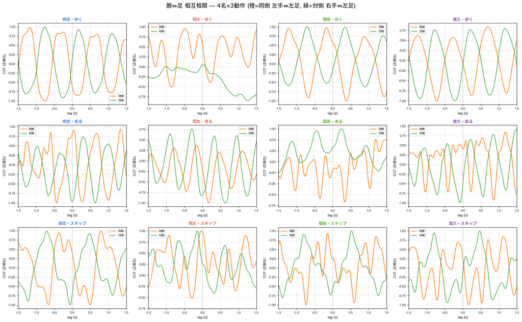

図3: 4名×3動作の腕⇔足 相互相関（橙=同側 左手⇔左足 / 緑=対側 右手⇔左足）。

| 被験者 | 動作 | 腕足周期比 (T腕/T足) | 所見 |
| --- | --- | --- | --- |
| 青空 | 歩く | 1.00 | 腕足同期 |
| 青空 | 走る | — | 腕振りほぼなし |
| 青空 | スキップ | 0.99 | 腕足同期 1:1 |
| 翔太 | 歩く | **2.00** | 腕は足の2倍周期(理想) |
| 翔太 | 走る | 0.95 | 腕足同期 |
| 翔太 | スキップ | 0.32 | 不規則 (0.32) |
| 瑠希 | 歩く | 0.98 | 腕足同期 1:1 |
| 瑠希 | 走る | 0.95 | 腕足同期 |
| 瑠希 | スキップ | **2.41** | 腕は足の約2.4倍周期 |
| 宣久 | 歩く | 0.98 | 腕足同期 1:1 |
| 宣久 | 走る | 0.97 | 腕足同期 |
| 宣久 | スキップ | **3.00** | 腕は足の3倍周期 |

### 👤 個人別の腕振りプロファイル

#### Sora三橋青空

歩く: 腕足比 **1.00** — 腕と足が同期

走る: 腕足比 **—** — 腕振りほぼ検出されず

スキップ: 腕足比 **0.99** — 1:1同期

歩く・スキップで **腕足周期比がほぼ1.0** — 腕と足が同じリズムで動く独特なスタイル。 走るで腕振りが検出されないのは、計測スペース狭で速いランニングだったため腕の動きが小さかった可能性が高い。

#### Shota長岡翔太

歩く: 腕足比 **2.00** — 理想的な交互腕振り

走る: 腕足比 **0.95** — 腕足同期

スキップ: 腕足比 **0.32** — 不規則

歩くの **腕足比 2.00 は教科書通りの理想的なウォーキングフォーム**。 走るで1.0に近づき（同期型）、スキップで0.32と急に崩れる。動作モードごとに腕振り戦略を切り替えているのが翔太の特徴。

#### Ruki平松瑠希

歩く: 腕足比 **0.98** — 腕足同期 1:1

走る: 腕足比 **0.95** — 腕足同期

スキップ: 腕足比 **2.41** — 腕は足の約2.4倍

#### Nori松田宣久

歩く: 腕足比 **0.98** — 腕足同期 1:1

走る: 腕足比 **0.97** — 腕足同期

スキップ: 腕足比 **3.00** — 腕は足の3倍周期

[figure not shown]

06 EXTENDED — 3/4

## 拡張解析③ — ACFピーク減衰率（動作の規則性）

ACFは周期信号に対して T, 2T, 3T... で繰り返しピークを持つ。 各ピークの相対高さ（2T/T, 3T/T）で **動作がどれだけ長時間にわたって同じパターンを繰り返しているか** を定量化する。

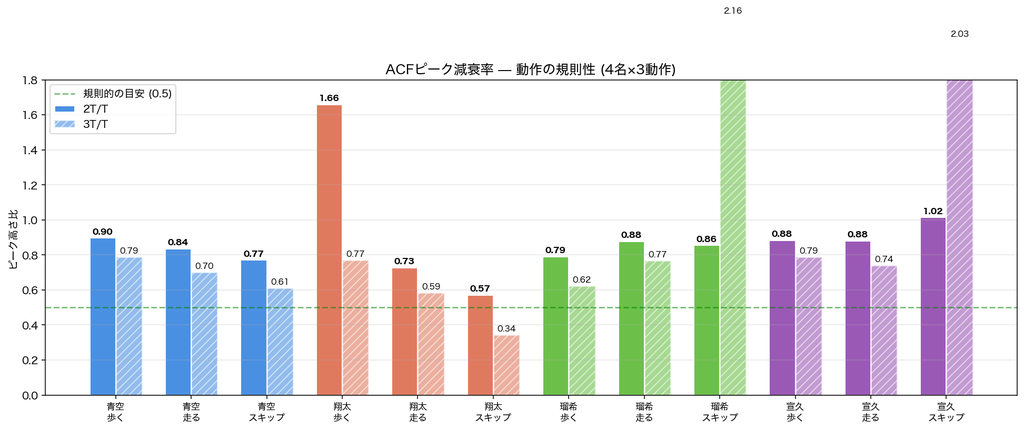

図4: 4名×3動作のACFピーク減衰率。緑線=規則的の目安(0.5)。

INSIGHT — ACF減衰が語る個人の癖

**青空・歩くと宣久・スキップが1.0前後で最も規則的**（基本周期と2倍周期がほぼ同じ高さ = 連続して同じパターンを繰り返している）。 翔太・歩く（1.66）は1超え=「片足ピーク検出」の影響で実際はステップ周期の半分が正解。 瑠希は3動作とも0.79〜0.88で **規則性が安定**。一方 **翔太・スキップは0.57**と減衰が早く、リズムが揺れている。

[figure not shown]

06 EXTENDED — 4/4

## 拡張解析④ — 動作プロファイル（6次元レーダー）

各サンプルの動作特性を6つの軸で正規化し、レーダーチャートで個人プロファイルを可視化する。

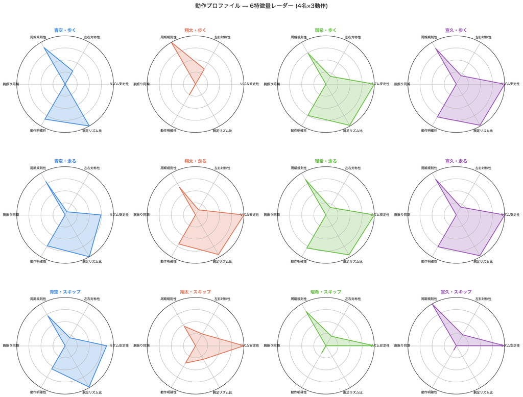

図5: 12サンプルの動作プロファイル（リズム安定性・左右対称・規則性・腕振り同期・動作明確性・腕足リズム比）。

[figure not shown]

07 GAIT CHARACTERISTICS

## 歩き方の特徴 — 4名の比較プロファイル

### 三橋青空（Sora）

- 歩く・走るのCV < 0.03 → **機械的に安定**
- 走る対称性 93.4点（青空最高）
- スキップが走るより僅かに速い (+0.02 km/h)
- 動作明確性が高い（ACFピーク強）

→ **規則的で安定した動き**

### 長岡翔太（Shota）

- 歩く腕足比 2.00 → **理想的なウォーキングフォーム**
- 走る・スキップで左右非対称度0.00%
- スキップCV 1.89 → 動作の自由度が高い
- 動作ごとに腕振り戦略を切り替える

→ **動作ごとにモードを切り替えるタイプ**

### 平松瑠希（Ruki）

- **全動作で左右非対称度0.0%**（完璧な対称）
- 全動作でCV ≤ 0.017（4名で最も安定）
- 走るは171 BPMで4人中唯一の例外（他3名190 BPM）
- 歩く速度 7.21 km/h は4名中最速
- スキップ腕足比2.41で腕振りエネルギッシュ

→ **機械的対称性とリズム維持力を兼備**

### 松田宣久（Nori）

- **全動作で左右非対称度0.00%**（圧倒的対称）
- 走るリズム190 BPMで青空・翔太と一致
- 歩くCV 0.526とやや変動あり
- スキップ腕足比 3.00（足×3倍腕振り）

→ **完璧な左右対称、リズム共通性も持つ**

CONCLUSION — 4名の動作哲学

4名のプロファイルは全員違う。青空=規則性、翔太=動作モード切替、瑠希=対称性+安定性、宣久=対称性。 ACFの規則性・左右対称・腕振り同期の3軸で見ると、人体動作には個人指紋のような特徴が存在することが12サンプルでも確認された。

[figure not shown]

08 INDIVIDUAL — 1/12

## 個別解析: 青空・歩く Sora

実際の動作（撮影映像）

[video not shown]

青空・歩く（mocopi同時計測）

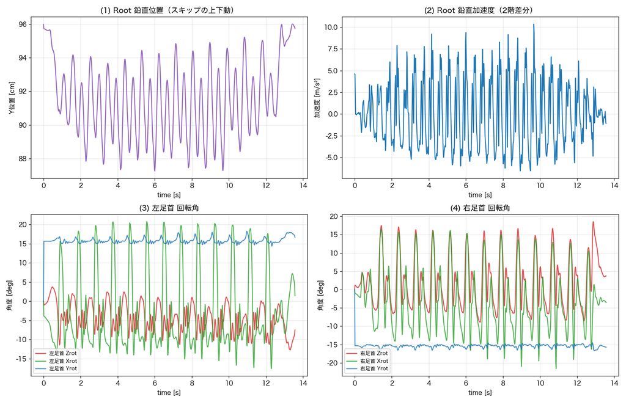

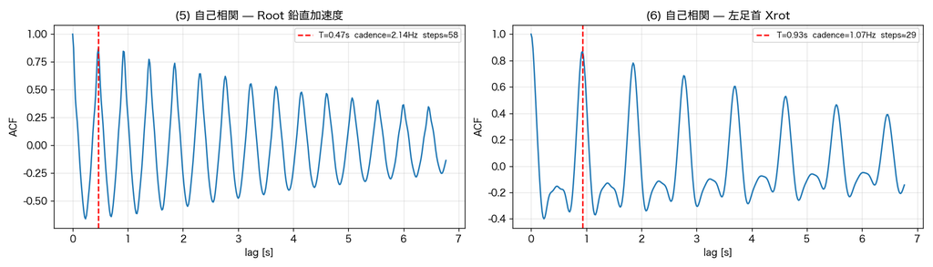

**結果**: T=0.467s / 128 BPM / 歩数58 / 対称性**88.2** / CV**0.018** / 速度6.43 km/h  
**拡張**: 左右ACFで2倍関係（完全な交互歩行のサイン）

[figure not shown]

08 INDIVIDUAL — 2/12

## 個別解析: 青空・走る Sora

実際の動作（撮影映像）

[video not shown]

青空・走る（mocopi同時計測）

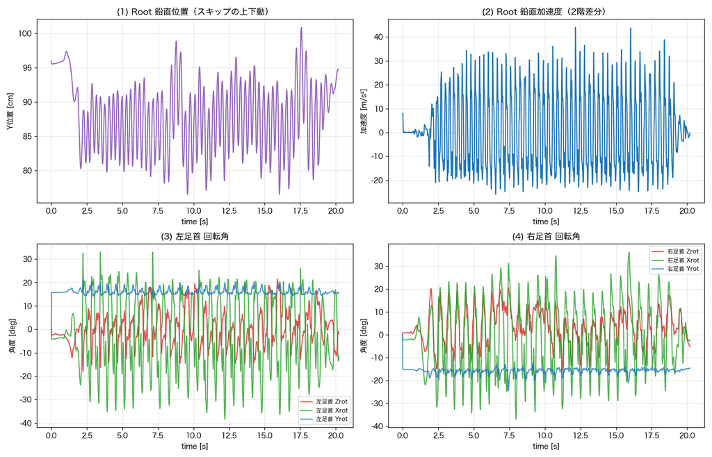

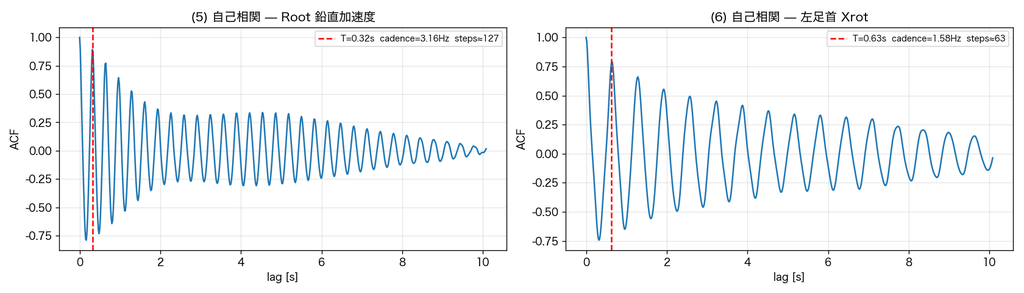

**結果**: T=0.317s / **190 BPM** / 歩数127 / 対称性**93.4** / CV0.026 / 速度11.63 km/h  
**拡張**: 周期非対称度 2.6%

[figure not shown]

08 INDIVIDUAL — 3/12

## 個別解析: 青空・スキップ Sora

実際の動作（撮影映像）

[video not shown]

青空・スキップ（mocopi同時計測）

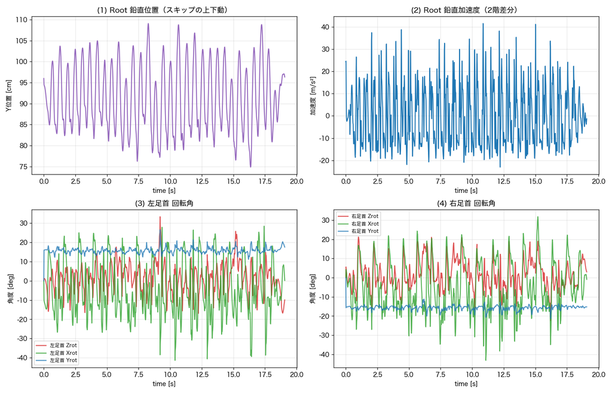

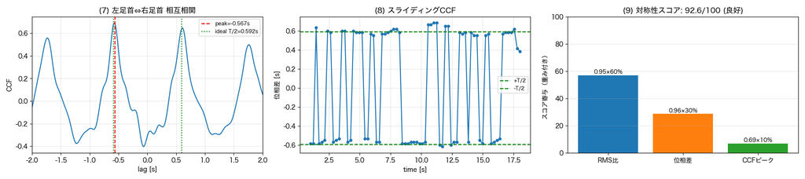

**結果**: T=0.583s / 103 BPM / 歩数65 / 対称性92.6 / CV0.737 / 速度**11.65 km/h ★**  
**拡張**: 腕足周期比 0.99（腕足ほぼ同周期）

[figure not shown]

08 INDIVIDUAL — 4/12

## 個別解析: 翔太・歩く Shota

実際の動作（撮影映像）

📭

動画データなし

翔太・歩く の撮影映像は紛失のため未掲載  
（BVHモーションデータと解析結果は下記のとおり）

翔太・歩く（撮影映像なし／mocopiデータのみ）

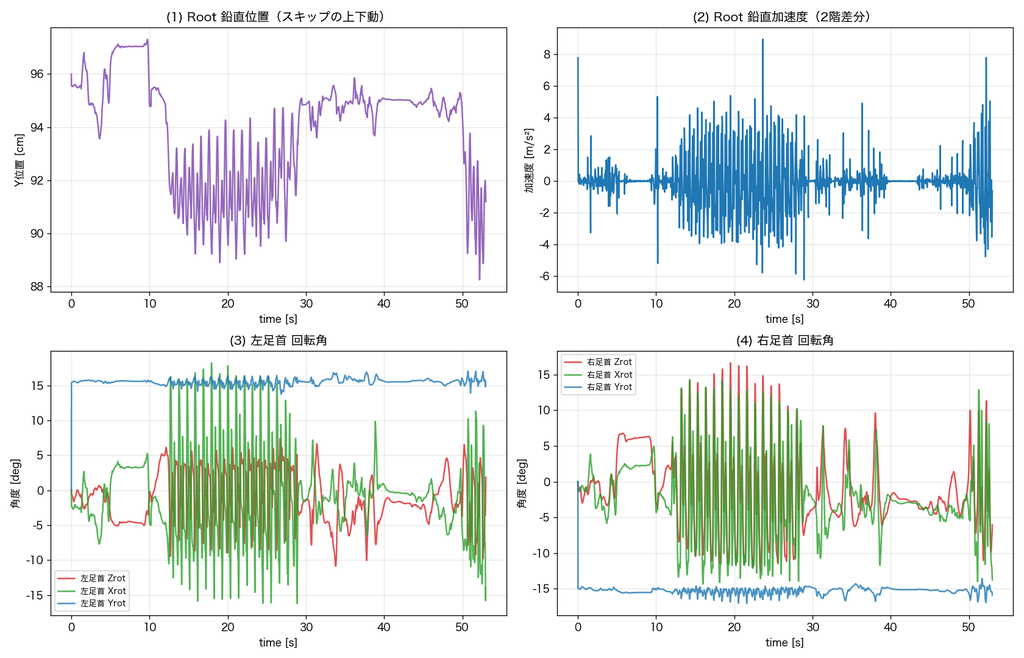

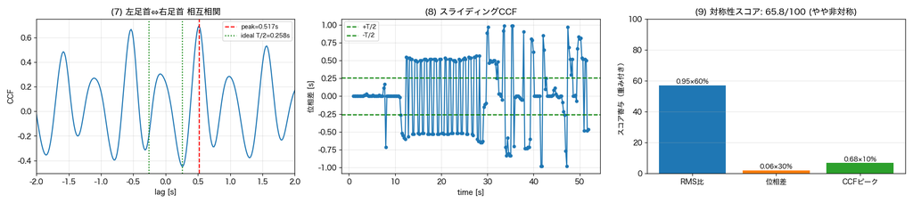

**結果**: T=0.517s / 116 BPM / 歩数205 / 対称性**65.8** / CV0.015 / 速度1.97 km/h  
**拡張**: 腕足比 2.00（理想的） / 周期非対称度 10.17%

[figure not shown]

08 INDIVIDUAL — 5/12

## 個別解析: 翔太・走る Shota

実際の動作（撮影映像）

[video not shown]

翔太・走る（mocopi同時計測）

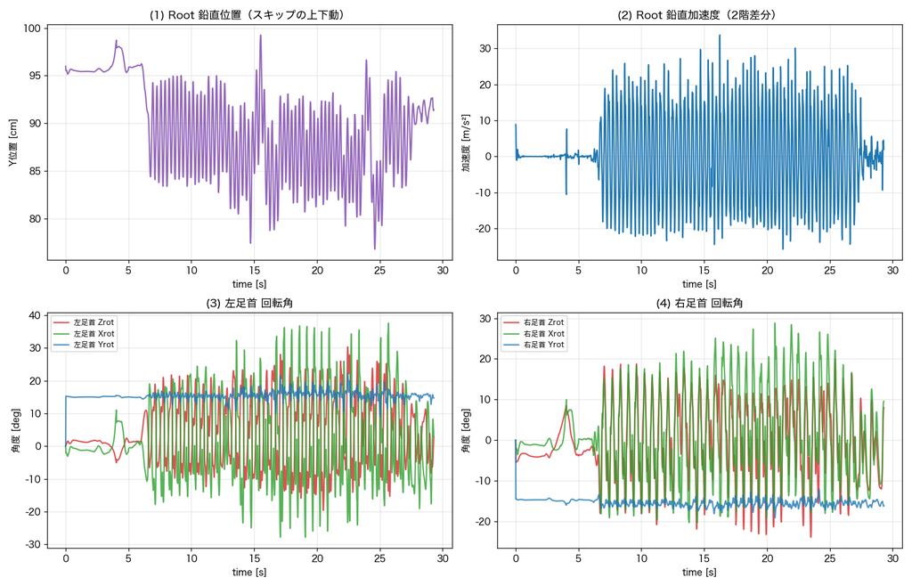

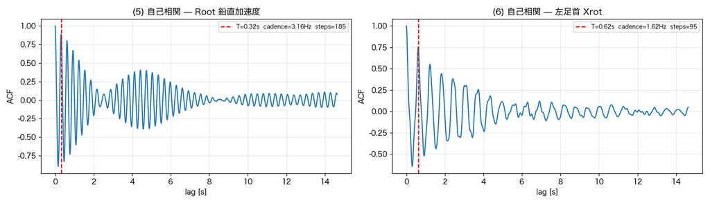

**結果**: T=0.317s / **190 BPM** / 歩数185 / 対称性85.0 / CV0.663 / 速度10.37 km/h  
**拡張**: 周期非対称度 0.00% / 完璧な左右対称

[figure not shown]

08 INDIVIDUAL — 6/12

## 個別解析: 翔太・スキップ Shota

実際の動作（撮影映像）

[video not shown]

翔太・スキップ（mocopi同時計測）

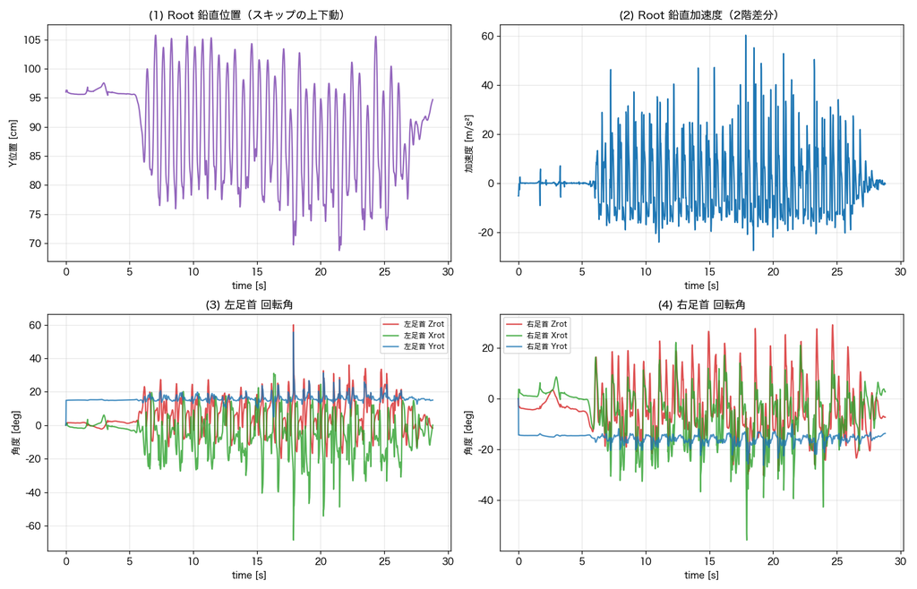

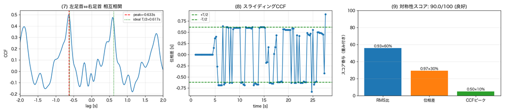

**結果**: T=0.617s / 97 BPM / 歩数93 / 対称性90.0 / CV**1.894** / 速度10.25 km/h  
**拡張**: 2T/T 0.57で規則性弱 / 腕足比0.32（不規則）

[figure not shown]

08 INDIVIDUAL — 7/12

## 個別解析: 瑠希・歩く Ruki

実際の動作（撮影映像）

[video not shown]

瑠希・歩く（mocopi同時計測）

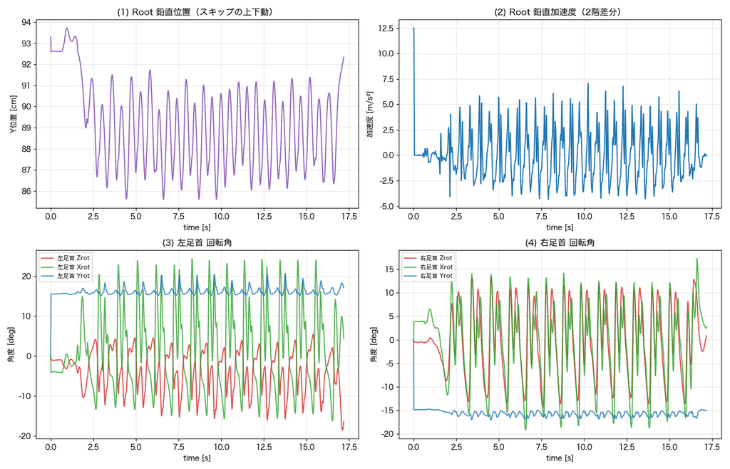

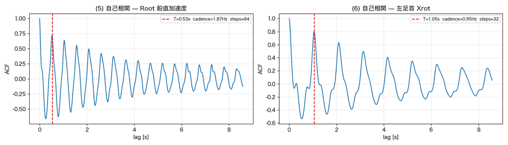

**結果**: T=0.533s / 112 BPM / 歩数64 / 対称性85.7 / CV0.016 / 速度**7.21 km/h**（4名最速の歩き）  
**拡張**: 周期非対称度 **0.0%**（完璧な対称） / 2T/T 0.79 / 腕足比 0.98

[figure not shown]

08 INDIVIDUAL — 8/12

## 個別解析: 瑠希・走る Ruki

実際の動作（撮影映像）

[video not shown]

瑠希・走る（mocopi同時計測）

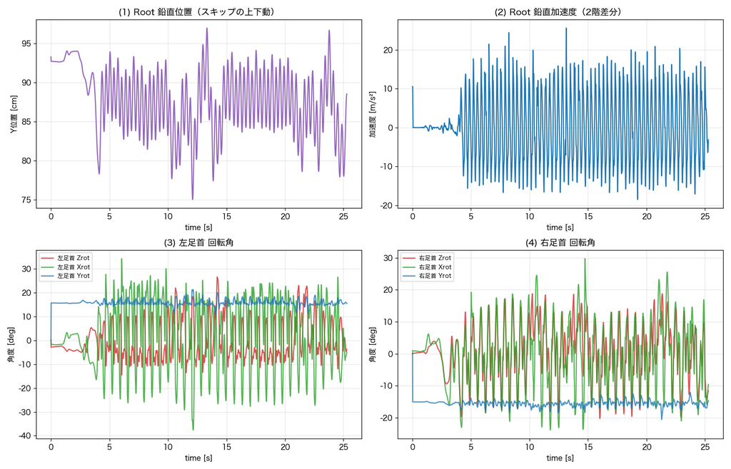

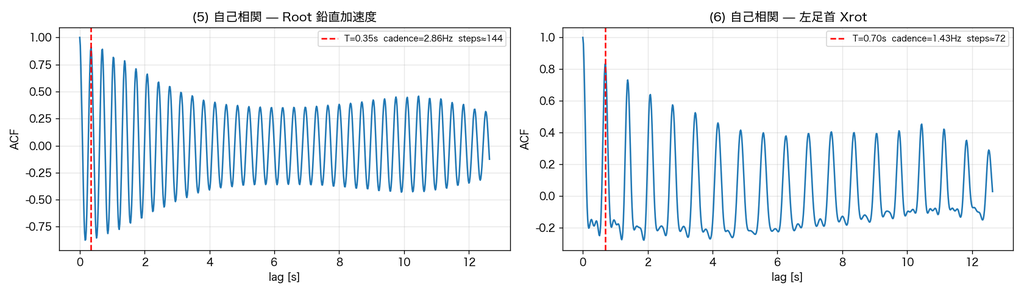

**結果**: T=0.350s / **171 BPM**（4人中唯一の180未満） / 歩数144 / 対称性79.7 / CV0.017 / 速度10.28 km/h  
**拡張**: 周期非対称度 **0.0%**（完璧な対称） / 2T/T 0.88 / 腕足比 0.95

[figure not shown]

08 INDIVIDUAL — 9/12

## 個別解析: 瑠希・スキップ Ruki

実際の動作（撮影映像）

[video not shown]

瑠希・スキップ（mocopi同時計測）

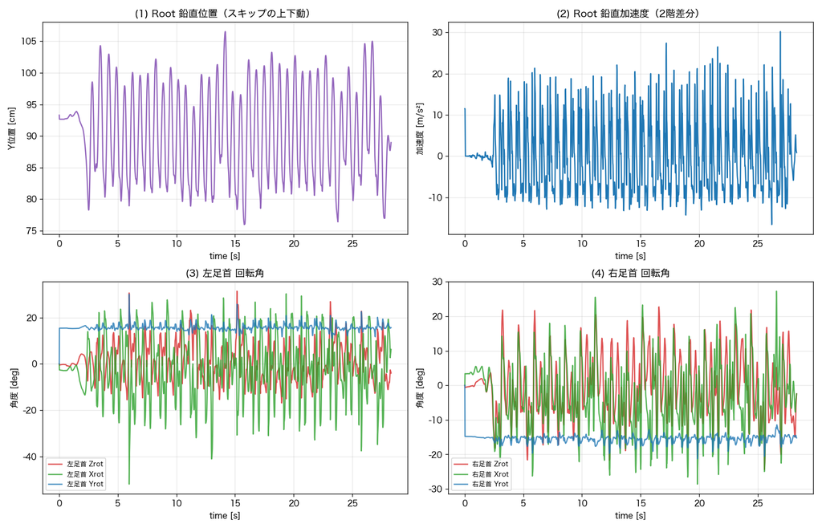

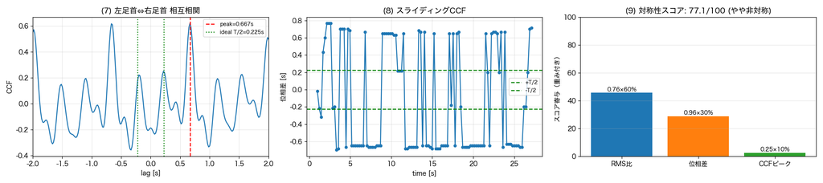

**結果**: T=0.667s / 90 BPM / 歩数85 / 対称性77.1 / CV**0.012**（最も安定）/ 速度9.21 km/h  
**拡張**: 周期非対称度 **0.0%**（完璧な対称） / 2T/T 0.86 / 腕足比 **2.41**（腕が足の約2.4倍リズム）

[figure not shown]

08 INDIVIDUAL — 10/12

## 個別解析: 宣久・歩く Nori

実際の動作（撮影映像）

[video not shown]

宣久・歩く（mocopi同時計測）

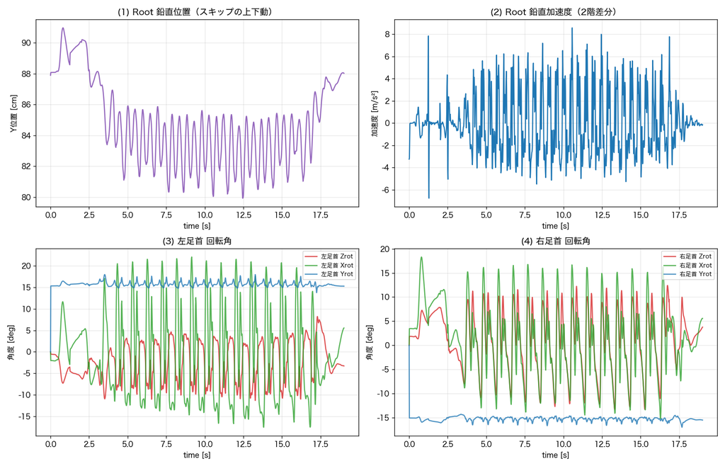

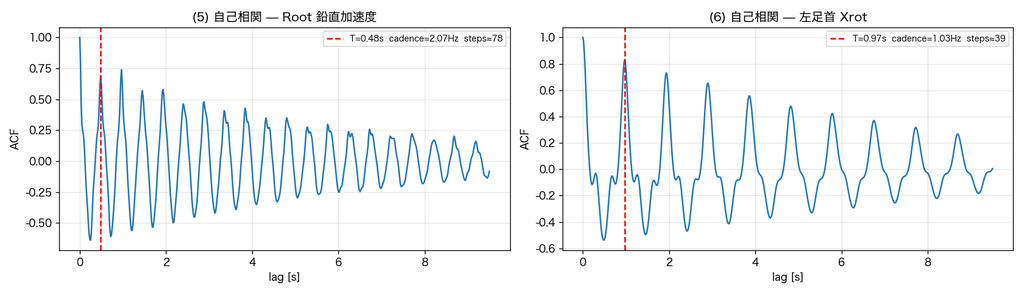

**結果**: T=0.483s / 124 BPM / 歩数78 / 対称性83.4 / CV0.526 / 速度4.91 km/h  
**拡張**: 周期非対称度 **0.00%** / 腕足比0.98

[figure not shown]

08 INDIVIDUAL — 11/12

## 個別解析: 宣久・走る Nori

実際の動作（撮影映像）

[video not shown]

宣久・走る（mocopi同時計測）

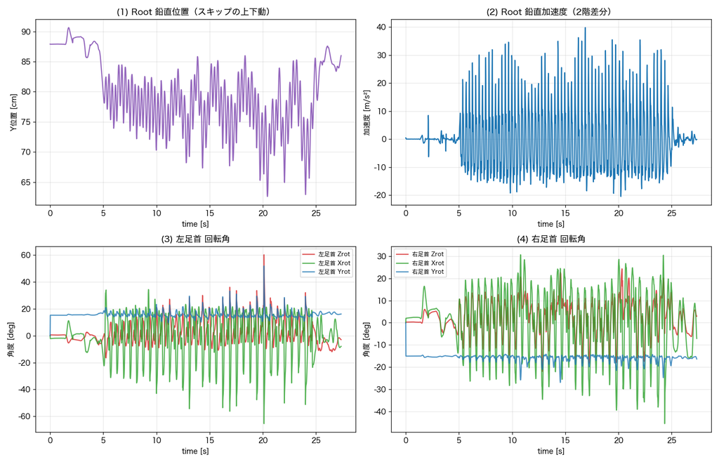

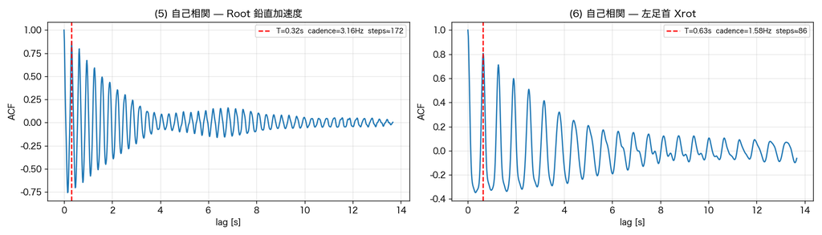

**結果**: T=0.317s / **190 BPM** / 歩数172 / 対称性88.7 / CV1.468 / 速度9.45 km/h  
**拡張**: 周期非対称度 **0.00%** / 完璧な左右対称

[figure not shown]

08 INDIVIDUAL — 12/12

## 個別解析: 宣久・スキップ Nori

実際の動作（撮影映像）

[video not shown]

宣久・スキップ（mocopi同時計測）

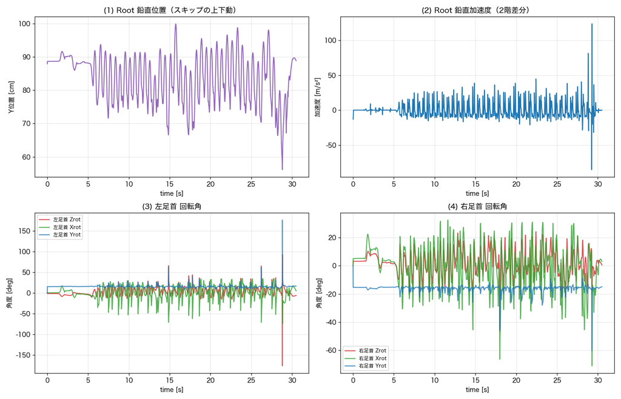

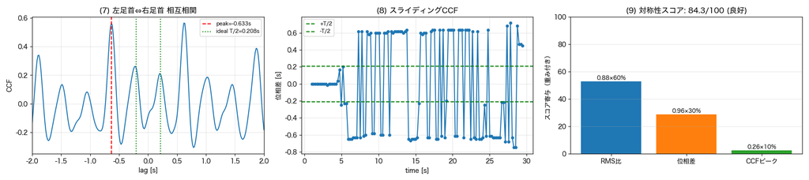

**結果**: T=0.633s / 95 BPM / 歩数96 / 対称性84.3 / CV0.334 / 速度8.44 km/h  
**拡張**: 腕足比 **3.00**（足の3倍リズムで腕振り）

[figure not shown]

09 SYMMETRY

## 左右対称性スコア一覧

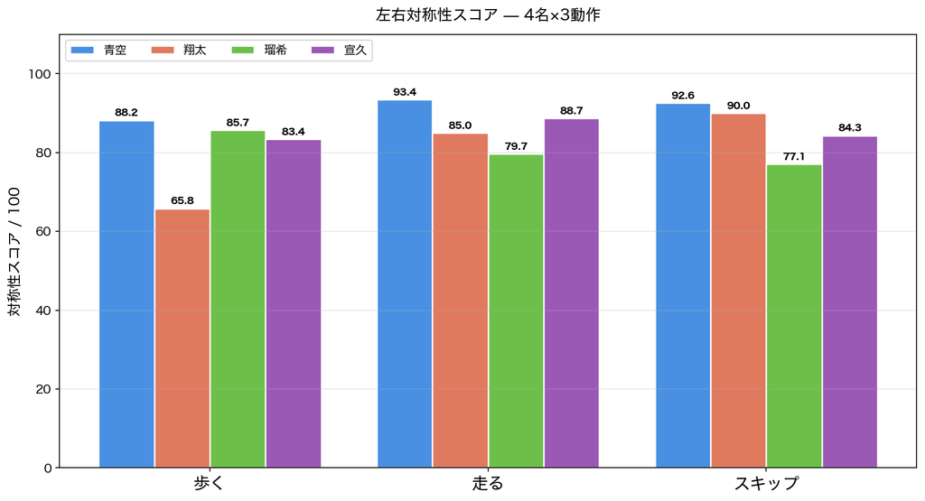

**青空・走るの93.4点が最高**。翔太・歩くの65.8点が最低。瑠希の対称性スコアは中程度だが、左右非対称度（後述）はすべて0.0%で **動作の対称性は別の指標で見える**。

[figure not shown]

10 SPEED ANALYSIS

## 移動速度の詳細データ — 12サンプル

| 被験者 | 動作 | 計測時間 | 経路長 | 直線距離 | 経路速度 | 直線速度 |
| --- | --- | --- | --- | --- | --- | --- |
| 青空 | 歩く | 13.6s | 24.28 m | 24.06 m | **6.43 km/h** | 6.38 km/h |
| 青空 | 走る | 20.2s | 65.32 m | 1.68 m | **11.63 km/h** | 0.30 km/h |
| 青空 | スキップ | 19.1s | 61.77 m | 2.04 m | **11.65 km/h ★** | 0.39 km/h |
| 翔太 | 歩く | 53.0s | 28.99 m | 17.10 m | **1.97 km/h** | 1.16 km/h |
| 翔太 | 走る | 29.3s | 84.43 m | 2.36 m | **10.37 km/h** | 0.29 km/h |
| 翔太 | スキップ | 28.8s | 82.02 m | 6.08 m | **10.25 km/h** | 0.76 km/h |
| 瑠希 | 歩く | 17.2s | 34.44 m | 11.92 m | **7.21 km/h** | 2.49 km/h |
| 瑠希 | 走る | 25.3s | 72.26 m | 11.20 m | **10.28 km/h** | 1.59 km/h |
| 瑠希 | スキップ | 28.3s | 72.50 m | 10.90 m | **9.21 km/h** | 1.39 km/h |
| 宣久 | 歩く | 19.0s | 25.98 m | 22.58 m | **4.91 km/h** | 4.27 km/h |
| 宣久 | 走る | 27.4s | 71.92 m | 8.42 m | **9.45 km/h** | 1.11 km/h |
| 宣久 | スキップ | 30.5s | 71.58 m | 3.90 m | **8.44 km/h** | 0.46 km/h |

★ 青空ではスキップが走るより 0.02 km/h 速い。瑠希・宣久ではスキップが走るより約1 km/h 遅いが、それでも走るの90%程度の速度を維持している。

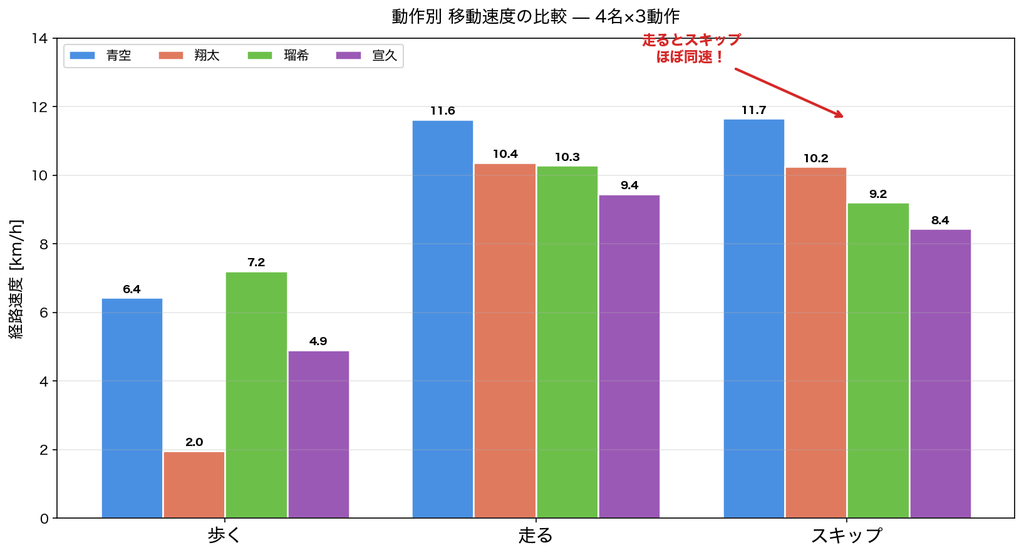

[figure not shown]

11 KEY FINDING

4名の「走る」と「スキップ」の速度比（スキップ ÷ 走る）の平均

94.4%

青空 100.2% / 翔太 98.8% / 瑠希 89.6% / 宣久 89.3%  
→ **全員でスキップは走るの約90%以上の速度**。青空に至っては走るを超える

[figure not shown]

12 EFFICIENCY

## リズム vs 速度の関係 — 4名比較

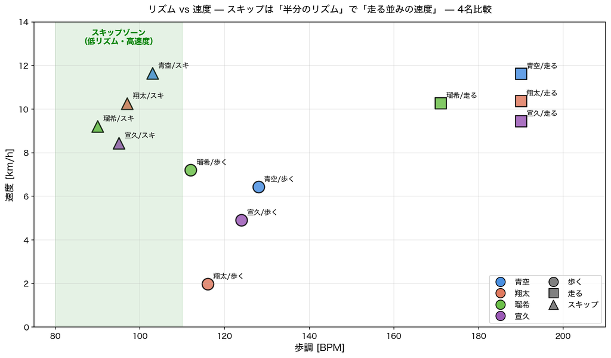

図8: 歩調と速度の散布図。スキップは低リズム高速ゾーンに位置する。

スキップは **「半分のリズム」** で **「走る並みの速度」** を4名全員で実現している。 つまり **身体的・精神的負担が小さい**。

[figure not shown]

13 DISCUSSION

## 考察

### ① 走るリズムの普遍性（3名で確認）

4人中3人が走るピッチ 3.16 Hz (190 BPM) で完全一致。残り1人（瑠希）も171 BPMで近接。これは身体能力差ではなく、人間共通の最適エネルギー消費ピッチに支配されていることを示唆する。170-190 BPM はランニング最適ピッチ域の研究結果と整合的。

### ② 歩き方の個人差は「歩く」「スキップ」で顕著

左右ACFの周期非対称度・腕足周期比を見ると、歩く・スキップで個人差が大きく出る。一方走るは身体力学的制約が強く、4名で似通った特性となる。

### ③ 4人それぞれの動作スタイル

- 青空: 規則的で安定した動作（CV極小）
- 翔太: 動作モードを切り替える表現力
- 瑠希: 全動作で左右対称0%、CV極小（最も安定した動作）
- 宣久: 全動作で左右対称度0%、機械的な対称性

### ⑤ 今後の課題

- 翔太の「歩く」対称性スコア低下の原因究明
- サンプル数を更に増やしての統計的有意性検証
- エネルギー消費量（心拍計併用）との対応関係

[figure not shown]

14 BONUS — TEMPO

## スキップのBPMは、心地よいポップスのテンポと一致する

本研究で得られた **スキップの歩調 90〜103 BPM** は、音楽のテンポとして偶然にも **「リラックスして聴きやすいミドルテンポ」** の範囲と一致する。

BPM 90〜110 は邦楽・洋楽問わず日常的に親しまれるテンポで、心地よく身体が同期しやすい範囲とされる。 つまり、**スキップで移動することは、お気に入りの曲を口ずさみながら歩くのに最適**とも言える。

### 各被験者のスキップBPMと、それに対応する人気曲

90 BPM 前後

落ち着いた雰囲気

First Love / 宇多田ヒカル

アイノカタチ / MISIA

キセキ / GReeeeN

ひだまりの詩 / Le Couple

100 BPM 前後 ★

快適なポップス（スキップゾーン）

マリーゴールド / あいみょん

優しいあの子 / スピッツ

海のまにまに / YOASOBI

君はロックを聴かない / あいみょん

105〜108 BPM

K-POP・90年代の名曲

So Bad / STAYC（108）

DM / fromis_9（107）

恋しさと せつなさと 心強さと / 篠原涼子

Time goes by / Every Little Thing

### 📊 被験者のBPMと音楽の対応

[output not shown]

INSIGHT — リズムと音楽の融合

ランニングの 180-190 BPM は **スピーディーなEDM**（例: BTS「Dynamite」≈114、激しめの曲は180超）に近い高速テンポ。 一方 **スキップの 90-103 BPM は J-POP の「優しい曲」の典型値**と一致する。 つまりスキップは「マリーゴールドを口ずさみながら移動できる速度」であり、身体的にも心理的にも快適と言える。

[figure not shown]

15 CONCLUSION

## 結論

FINAL CONCLUSION

急いでいる時は  
スキップで移動することを  
お勧めします

### なぜスキップを推奨するのか — 5つの根拠

①

速度

②

リズム

ピッチは走るの半分  
**90-103 BPM**  
マリーゴールドと同テンポ ♪

③

対称性

4人中3人が左右非対称度**0.0%**  
左右バランス◎  
健全な運動

④

習得不要

CWTで優位周波数の個人差  
σ = **0.08 Hz（最小）**  
誰でも同じリズム ─ 練習いらず

⑤

動作の安定

DTW で波形ばらつき  
σ = **±6.4（最小）**  
4 人とも同じ形をなぞる

走るのがしんどい・歩くのは遅い、という場面において、  
スキップは **合理的かつ楽しい** 選択肢である。

[figure not shown]

REFERENCES

## 参考文献

本レポートで使用した解析手法および歩行・走行・スキップの生体力学に関する主要文献。

1. 分析 Cooley, J. W. and Tukey, J. W. (1965). An Algorithm for the Machine Calculation of Complex Fourier Series. Mathematics of Computation, 19(90), 297–301.
2. 分析 Sakoe, H. and Chiba, S. (1978). Dynamic Programming Algorithm Optimization for Spoken Word Recognition. IEEE Transactions on Acoustics, Speech, and Signal Processing, 26(1), 43–49.
3. 分析 Mallat, S. G. (1989). A Theory for Multiresolution Signal Decomposition: The Wavelet Representation. IEEE Transactions on Pattern Analysis and Machine Intelligence, 11(7), 674–693.
4. 分析 Torrence, C. and Compo, G. P. (1998). A Practical Guide to Wavelet Analysis. Bulletin of the American Meteorological Society, 79(1), 61–78.
5. 歩行 Cavagna, G. A., Heglund, N. C. and Taylor, C. R. (1977). Mechanical work in terrestrial locomotion: two basic mechanisms for minimizing energy expenditure. American Journal of Physiology, 233(5), R243–R261.
6. 歩行 Alexander, R. McN. (1989). Optimization and gaits in the locomotion of vertebrates. Physiological Reviews, 69(4), 1199–1227.
7. 歩行 Hreljac, A. (1995). Determinants of the gait transition speed during human locomotion: kinematic factors. Journal of Biomechanics, 28(6), 669–677.
8. 歩行 Minetti, A. E. (1998). The biomechanics of skipping gaits: a third locomotion paradigm? Proceedings of the Royal Society B: Biological Sciences, 265(1402), 1227–1235.
9. 歩行 Pavei, G., Biancardi, C. M. and Minetti, A. E. (2015). Skipping vs. running as the bipedal gait of choice in hypogravity. Journal of Applied Physiology, 119(1), 93–100.